# Tensorflow Tutorial (writen by experience)

### The most basic DNN

l1 = tf.layers.dense(tf_x, 10, tf.nn.relu)

tf.layers.dense(

```
inputs,

units,

activation=None,

use_bias=True,

kernel_initializer=None,

bias_initializer=tf.zeros_initializer(),

bias_regularizer=None,

activity_regularizer=None,

kernel_constraint=None,

bias_constraint=None,

trainable=True,

name=None,

reuse=None
```

)

```python
import tensorflow as tf
import matplotlib.pyplot as plt
import numpy as np
import os

np.random.seed(1)

# fake data
n_data = np.ones((100, 2))
x0 = np.random.normal(2*n_data, 1)      # class0 x shape=(100, 2)
y0 = np.zeros(100)                      # class0 y shape=(100, )
x1 = np.random.normal(-2*n_data, 1)     # class1 x shape=(100, 2)
y1 = np.ones(100)                       # class1 y shape=(100, )
x = np.vstack((x0, x1))
y = np.hstack((y0, y1))
```

```python
tf.reset_default_graph()
tf.set_random_seed(1)
tf_x = tf.placeholder(tf.float32, x.shape)     # input x
tf_y = tf.placeholder(tf.int32, y.shape)     # input y

# neural network layers
# it's important to use gaussian distribution to initialize weight, it matters a lot!!! but it's not so important for bias
l1 = tf.layers.dense(tf_x, 10, tf.nn.relu,use_bias=True,kernel_initializer=tf.random_normal_initializer,bias_initializer=tf.zeros_initializer(),kernel_regularizer=tf.contrib.layers.l2_regularizer(0.003),name="layer1")

output = tf.layers.dense(l1, 2)

loss = tf.losses.sparse_softmax_cross_entropy(labels=tf_y, logits=output)
accuracy = tf.metrics.accuracy(
    labels=tf.squeeze(tf_y), predictions=tf.argmax(output, axis=1),)[1]
optimizer = tf.train.GradientDescentOptimizer(learning_rate=0.05)
train_op = optimizer.minimize(loss)

sess = tf.Session()
init_op = tf.group(tf.global_variables_initializer(), tf.local_variables_initializer())
sess.run(init_op)

for i in range(50):
    _, acc, pred = sess.run([train_op, accuracy, output], {tf_x: x, tf_y: y})
    if i%5==0:
        print("Current accuracy is %s"%str(acc))
```

```
Current accuracy is 0.095
Current accuracy is 0.595
Current accuracy is 0.7540909
Current accuracy is 0.83
Current accuracy is 0.8704762
Current accuracy is 0.8953846
Current accuracy is 0.9122581
Current accuracy is 0.92444444
Current accuracy is 0.9332927
Current accuracy is 0.94
```

**Read the parameter, although it's inconvenient in tensorflow, but let's overcome it**

```python
t_vars = tf.trainable_variables()
print(t_vars)
```

```
[<tf.Variable 'layer1/kernel:0' shape=(2, 10) dtype=float32_ref>, <tf.Variable 'layer1/bias:0' shape=(10,) dtype=float32_ref>, <tf.Variable 'dense/kernel:0' shape=(10, 2) dtype=float32_ref>, <tf.Variable 'dense/bias:0' shape=(2,) dtype=float32_ref>]
```

```python
tf.reset_default_graph()
tf.set_random_seed(1)
tf_x = tf.placeholder(tf.float32, x.shape)     # input x
tf_y = tf.placeholder(tf.int32, y.shape)     # input y

# neural network layers
# it's important to use gaussian distribution to initialize weight, it matters a lot!!! but it's not so important for bias
l1 = tf.layers.dense(tf_x, 10, tf.nn.relu,use_bias=True,kernel_initializer=tf.random_normal_initializer,bias_initializer=tf.zeros_initializer(),kernel_regularizer=tf.contrib.layers.l2_regularizer(0.003),name="layer1")

output = tf.layers.dense(l1, 2)

loss = tf.losses.sparse_softmax_cross_entropy(labels=tf_y, logits=output)
accuracy = tf.metrics.accuracy(
    labels=tf.squeeze(tf_y), predictions=tf.argmax(output, axis=1),)[1]
optimizer = tf.train.GradientDescentOptimizer(learning_rate=0.05)
train_op = optimizer.minimize(loss)


w=tf.get_default_graph().get_tensor_by_name('layer1/kernel:0')
b=tf.get_default_graph().get_tensor_by_name('layer1/bias:0')

sess = tf.Session()
init_op = tf.group(tf.global_variables_initializer(), tf.local_variables_initializer())
sess.run(init_op)

for i in range(50):
    _, acc,w_,b_, pred = sess.run([train_op, accuracy,w,b, output], {tf_x: x, tf_y: y})
    if i%10==0:
        print("Current accuracy is %s"%str(acc))
        print("Current weight is %s"%str(w_))
        print("Current bias is %s"%str(b_))
```

```
Current accuracy is 0.095
Current weight is [[ 3.0443466e-01  1.7411395e+00  1.3745018e+00 -1.0424273e-01
  -4.6988225e-01 -4.6120360e-01 -1.7121072e+00 -1.6727335e+00
  -8.3083373e-01  2.2538664e-02]
 [-5.5461740e-01 -2.8682300e-01 -7.9140431e-01 -1.7611562e-01
   5.9389138e-01 -1.9742915e-01 -9.9037594e-01 -5.8771962e-01
   1.8272741e+00 -1.7781332e-03]]
Current bias is [ 0.00556271 -0.0138352  -0.01492386  0.02181677  0.00042728 -0.01171083
 -0.01896556  0.01170096  0.00237693 -0.01879849]
Current accuracy is 0.7540909
Current weight is [[ 0.21696378  1.6977557   1.2273297  -0.16562636 -0.4254397  -0.43461892
  -1.6822027  -1.7235277  -0.76647675  0.23546213]
 [-0.5918839  -0.31885517 -0.8838111  -0.21657479  0.629504   -0.18013828
  -0.970755   -0.620436    1.8752449   0.1272209 ]]
Current bias is [-0.00450875 -0.03131659 -0.0674342   0.05137807  0.00946226 -0.02419437
 -0.03281812  0.03590937  0.02214148  0.06500915]
Current accuracy is 0.8704762
Current weight is [[ 0.19794531  1.7129724   1.2093086  -0.17931028 -0.41628453 -0.42911297
  -1.6779872  -1.7377709  -0.75008476  0.2829044 ]
 [-0.6000192  -0.31053877 -0.8934585  -0.22762547  0.63581437 -0.17640325
  -0.96790063 -0.6301079   1.8860139   0.15134141]]
Current bias is [-0.00527589 -0.02532846 -0.07336225  0.06131621  0.01094273 -0.02757333
 -0.03539989  0.04466008  0.02665866  0.08466339]
Current accuracy is 0.9122581
Current weight is [[ 0.18933916  1.7232745   1.2018392  -0.1869749  -0.4110609  -0.4259044
  -1.6758997  -1.7467592  -0.74038047  0.3067717 ]
 [-0.605462   -0.30377972 -0.89826965 -0.23573607  0.63942546 -0.17397882
  -0.96632487 -0.6369025   1.8924071   0.1654318 ]]
Current bias is [-0.00428939 -0.02126944 -0.07562596  0.06860747  0.01172999 -0.02977711
 -0.03683228  0.05083634  0.02927418  0.09502027]
Current accuracy is 0.9332927
Current weight is [[ 0.18383798  1.7310468   1.1973238  -0.1920105  -0.4072106  -0.42365617
  -1.6746163  -1.7533886  -0.7331904   0.32275498]
 [-0.6099667  -0.29790077 -0.9016167  -0.24251218  0.64211786 -0.17214291
  -0.96527743 -0.64231735  1.8971823   0.17607541]]
Current bias is [-0.00300351 -0.01829489 -0.07686333  0.07467063  0.01238369 -0.03144385
 -0.03778324  0.05575223  0.03123035  0.10202774]
```

**DIY is always the best, regardless of the convenience**

```python
#define one layer
def dense_layer(inputs,name,units,w,mask,activation=None,use_bias=True,kernel_initializer=None):
        """Mimics tf.dense_layer but masks weights and uses presets as necessary."""
        # If there is a preset for this layer, use it.
        kernel_initializer = tf.constant_initializer(w)
        # Create the weights.
        weights = tf.get_variable(
            name=name + '_w',
            shape=[inputs.shape[1], units],
            initializer=kernel_initializer)

        # Mask the layer as necessary.
        mask_initializer = tf.constant_initializer(mask)
        mask = tf.get_variable(
              name=name + '_m',
              shape=[inputs.shape[1], units],
              initializer=mask_initializer,
              trainable=False)
        weights = tf.multiply(weights, mask)
        # Compute the output.
        output = tf.matmul(inputs, weights)

        # Add bias if applicable.
        if use_bias:
          bias = tf.get_variable(
              name=name + '_b', shape=[units], initializer=tf.zeros_initializer())
          output += bias

        # Activate.
        if activation:
          return activation(output),weights
        else:
          return output,weights
```

```python
l1,w1=dense_layer1(tf_x,'l1', 5, np.ones((x.shape[1],5)),mask,activation=tf.nn.relu)
```

**If you deal with multiple tasks, the initialization is really inconvenient in Tensorflow, but let's overcome it**

```python
def initialize_uninitialized(self,sess):

    global_vars          = tf.global_variables()
    initialized   = sess.run([tf.is_variable_initialized(var) for var in global_vars])
    not_initialized_vars = [v for (v, f) in zip(global_vars, initialized) if not f]

    if len(not_initialized_vars):
        sess.run(tf.variables_initializer(not_initialized_vars))
```

### Application1:

**Prune the DNN, change the structure**

Refer: ICLR 2019 Best Paper, The lottery ticket hypothesis: Finding sparse, trainable neural networks, https://arxiv.org/pdf/1803.03635.pdf

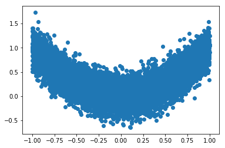

```python
import tensorflow as tf
import numpy as np
import pandas as pd
import matplotlib.pyplot as plt

#simulation data========================
x = np.linspace(-1, 1, 10000)[:, np.newaxis]
noise = np.random.normal(0, 0.2, size=x.shape)
y = np.power(x,2) + noise
mask=np.array([1,0,1,1,0])
plt.scatter(x,y)
```

```python
tf.reset_default_graph()
tf_x = tf.placeholder(tf.float32, [None,x.shape[1]])
tf_y = tf.placeholder(tf.int32, [None,1])
tf_is_training = tf.placeholder(tf.bool, None)
l1,w1=dense_layer(tf_x,'l1', 5, np.ones((x.shape[1],5)),mask,activation=tf.nn.relu)
output=tf.layers.dense(l1,1)
loss = tf.losses.mean_squared_error(tf_y, output)
optimizer = tf.train.GradientDescentOptimizer(learning_rate=0.5)
train_op = optimizer.minimize(loss)
sess = tf.Session()
sess.run(tf.global_variables_initializer())
for step in range(20):
    # train and net output
    _, loss_, pred,w1_= sess.run([train_op, loss, output,w1], {tf_x: x.reshape(-1,1), tf_y: y.reshape(-1,1)})
    #print(loss_)
    if (step-1)%5==0:
        print(w1_)
```

```
[[0.85398537 0.         0.9846996  0.93034655 0.        ]]
[[0.8083275 0.        0.9978401 0.9213897 0.       ]]
[[0.7884186  0.         1.006951   0.92004824 0.        ]]
[[0.78124225 0.         1.0098917  0.9200107  0.        ]]
```

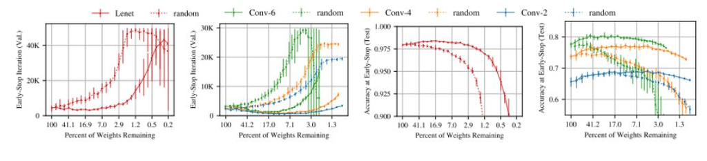

**This sparse structure can help the networks test faster, and get better test performance.**

### Application2:

**Use inexplicit formula（neural network） to represent factors, I know it maybe hard to accept at first, but……**

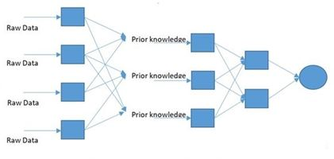

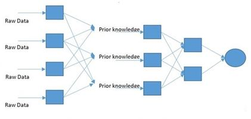

我个人认为，全连接是基础：

1.可能前期用全连接网络来做**数据增强**（除噪声、样本均衡）是很重要的。做一些全连接网络能做的**暴力搜索项目**（现在几家私募都在做这个，无量资本、悟空、幻方,只不过这几家目的很明确，现在就是在研究如何组合运算符和价量，搜索显式因子，但是目前的几种粗暴方式不尽如人意，最终挖到有效因子的情况不太清楚）

2.再或者是用全连接网络**探索网络结构**。在分类器层面提出比xgboost更合适的网络结构（自适应调整结构）